# Introduction to Python Project : FoodHub Data Analysis

### Problem Statement

The Customer face inconvenience using multiple apps/websites to order food, compare prices, and access divers cuisines, leading to a feagmented and time consuming experience.

Objective:

Food Aggregator company food Hub aims to provide a single smart phone app that connects users to multiple restaurant, offerring convinience variety, transparent pricing, reviews and real time order tracking.

They want to analyze the data to get a fair idea about the demad of diffrent restaurants which will help the company to enhancing their customer experience and increase busniess revenue

### Data Dictionary

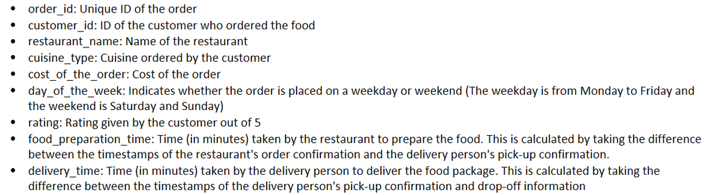

### Let us start by importing the required libraries

```python
pip install plotly
```

```python
# Write your code here to import necessary libraries for the project

import pandas as pd
import numpy as np
import matplotlib.pyplot as plt
import seaborn as sns
import plotly as pl
import warnings
warnings.filterwarnings("ignore")
```

# Understanding the structure of the data

```python
# uncomment and run the following lines for Google Colab
from google.colab import drive
drive.mount('/content/drive')
```

```python
# Write your code here to read the data

path = "/content/drive/MyDrive/AI and ML/Projects/foodhub_order.csv"

df  = pd.read_csv(path)
```

```python
# Write your code here to view the first 5 rows

print(df.head())
```

```
   order_id  customer_id            restaurant_name cuisine_type  \
0   1477147       337525                    Hangawi       Korean
1   1477685       358141  Blue Ribbon Sushi Izakaya     Japanese
2   1477070        66393                Cafe Habana      Mexican
3   1477334       106968  Blue Ribbon Fried Chicken     American
4   1478249        76942           Dirty Bird to Go     American

   cost_of_the_order day_of_the_week     rating  food_preparation_time  \
0              30.75         Weekend  Not given                     25
1              12.08         Weekend  Not given                     25
2              12.23         Weekday          5                     23
3              29.20         Weekend          3                     25
4              11.59         Weekday          4                     25

   delivery_time
0             20
1             23
2             28
3             15
4             24
```

### **Question 1:** How many rows and columns are present in the data? [0.5 mark]

```python
# Write your code here

print(df.shape)
```

```
(1898, 9)
```

### Observations:

Data set contains 1898 rows and 9 coloum.

### **Question 2:** What are the datatypes of the different columns in the dataset? (The info() function can be used) [0.5 mark]

```python
# Write your code here

print(df.info())
```

```
<class 'pandas.core.frame.DataFrame'>
RangeIndex: 1898 entries, 0 to 1897
Data columns (total 9 columns):
 #   Column                 Non-Null Count  Dtype
---  ------                 --------------  -----
 0   order_id               1898 non-null   int64
 1   customer_id            1898 non-null   int64
 2   restaurant_name        1898 non-null   object
 3   cuisine_type           1898 non-null   object
 4   cost_of_the_order      1898 non-null   float64
 5   day_of_the_week        1898 non-null   object
 6   rating                 1898 non-null   object
 7   food_preparation_time  1898 non-null   int64
 8   delivery_time          1898 non-null   int64
dtypes: float64(1), int64(4), object(4)
memory usage: 133.6+ KB
None
```

#### Observations:

Column like Order ID, Customer ID, Food preparation Time , Delivery time, Cost of order are numerical and restaurant_name, cuisine_type, day_of_the_week, rating are Categorical data.

### **Question 3:** Are there any missing values in the data? If yes, treat them using an appropriate method. [1 mark]

```python
# Write your code here

print(df.isnull().sum())
```

```
order_id                 0
customer_id              0
restaurant_name          0
cuisine_type             0
cost_of_the_order        0
day_of_the_week          0
rating                   0
food_preparation_time    0
delivery_time            0
dtype: int64
```

#### Observations:

After checking the dataset no missing value have been found however some are rating as "not given".

### **Question 4:** Check the statistical summary of the data. What is the minimum, average, and maximum time it takes for food to be prepared once an order is placed? [2 marks]

```python
# Write your code here

print(df.describe())
```

```
           order_id    customer_id  cost_of_the_order  food_preparation_time  \
count  1.898000e+03    1898.000000        1898.000000            1898.000000
mean   1.477496e+06  171168.478398          16.498851              27.371970
std    5.480497e+02  113698.139743           7.483812               4.632481
min    1.476547e+06    1311.000000           4.470000              20.000000
25%    1.477021e+06   77787.750000          12.080000              23.000000
50%    1.477496e+06  128600.000000          14.140000              27.000000
75%    1.477970e+06  270525.000000          22.297500              31.000000
max    1.478444e+06  405334.000000          35.410000              35.000000

       delivery_time
count    1898.000000
mean       24.161749
std         4.972637
min        15.000000
25%        20.000000
50%        25.000000
75%        28.000000
max        33.000000
```

#### Observations:

The statistical summary of the dataset shows that the preparation time for orders ranges from 20 minutes (minimum) to 35 minutes (maximum). Most orders are prepared within an average of 27.3 minutes, indicating an efficient kitchen process for most restaurants.

### **Question 5:** How many orders are not rated? [1 mark]

```python
# Write the code here

print(df.info())
```

```
<class 'pandas.core.frame.DataFrame'>
RangeIndex: 1898 entries, 0 to 1897
Data columns (total 9 columns):
 #   Column                 Non-Null Count  Dtype
---  ------                 --------------  -----
 0   order_id               1898 non-null   int64
 1   customer_id            1898 non-null   int64
 2   restaurant_name        1898 non-null   object
 3   cuisine_type           1898 non-null   object
 4   cost_of_the_order      1898 non-null   float64
 5   day_of_the_week        1898 non-null   object
 6   rating                 1898 non-null   object
 7   food_preparation_time  1898 non-null   int64
 8   delivery_time          1898 non-null   int64
dtypes: float64(1), int64(4), object(4)
memory usage: 133.6+ KB
None
```

```python
df['rating'].value_counts()
```

| rating | count |
| --- | --- |
| Not given | 736 |
| 5 | 588 |
| 4 | 386 |
| 3 | 188 |

**dtype:** int64

#### Observations:

In rating section, Around 736 order does not have rating.

### Exploratory Data Analysis (EDA)

### **Question 6:** Explore all the variables and provide observations on their distributions. (Generally, histograms, boxplots, countplots, etc. are used for univariate exploration.) [9 marks]

## **BOX PLOTS**

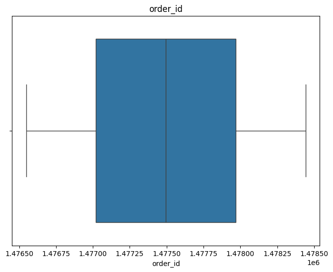

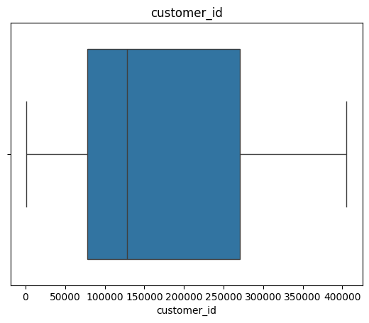

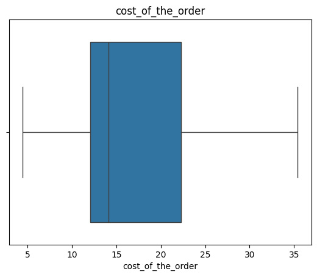

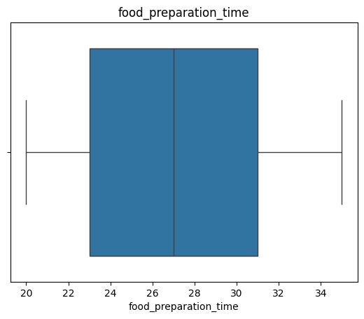

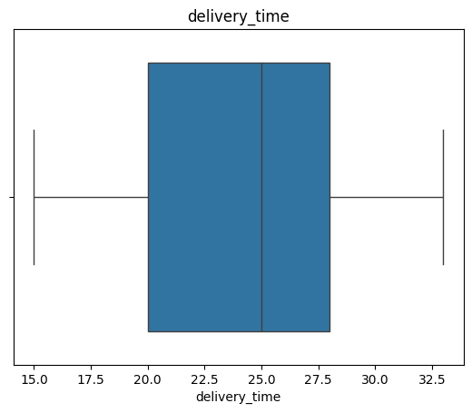

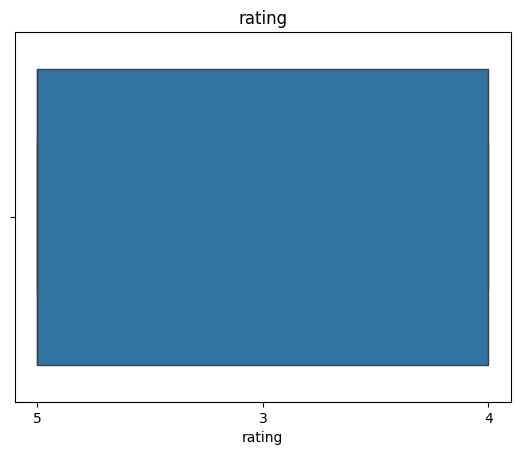

| restaurant_name | count |
| --- | --- |
| Shake Shack | 219 |
| The Meatball Shop | 132 |
| Blue Ribbon Sushi | 119 |
| Blue Ribbon Fried Chicken | 96 |
| Parm | 68 |

**dtype:** int64

```python
# Write the code here
df1 = df[df['rating'] != 'Not given']

plt.figure(figsize=(8, 6))
sns.boxplot(data=df, x='order_id')
plt.title('order_id')
plt.show()
sns.boxplot(data=df, x='customer_id')
plt.title('customer_id')
plt.show()
sns.boxplot(data=df, x='cost_of_the_order')
plt.title('cost_of_the_order')
plt.show()
sns.boxplot(data=df, x='food_preparation_time')
plt.title('food_preparation_time')
plt.show()
sns.boxplot(data=df, x='delivery_time')
plt.title('delivery_time')
plt.show()
sns.boxplot(data=df1, x='rating')
plt.title('rating')
plt.show()

df['restaurant_name'].value_counts().sort_values(ascending=False).head(5)
```

Histogram Charts

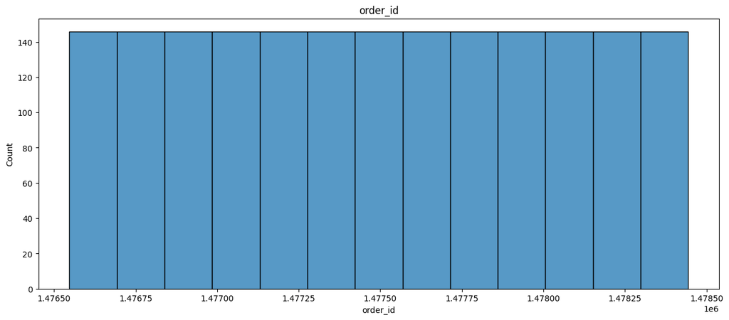

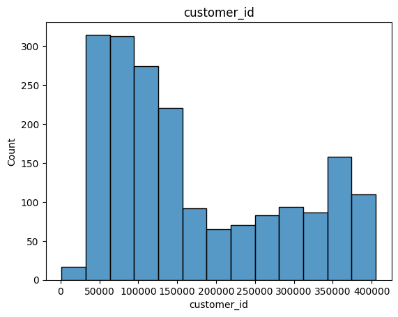

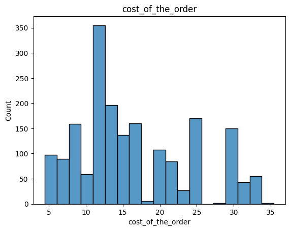

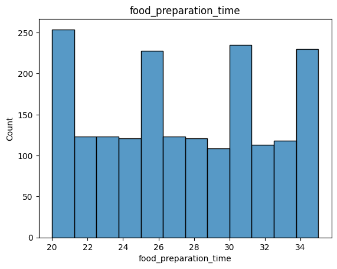

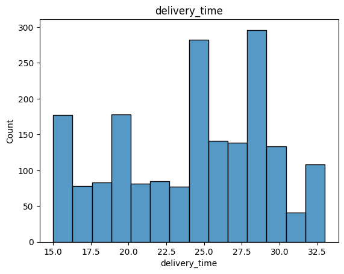

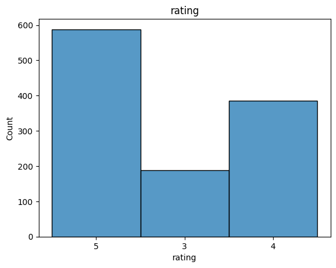

```python
plt.figure(figsize=(15, 6))
sns.histplot(data=df, x='order_id')
plt.title('order_id')
plt.show()
sns.histplot(data=df, x='customer_id')
plt.title('customer_id')
plt.show()
sns.histplot(data=df, x='cost_of_the_order')
plt.title('cost_of_the_order')
plt.show()
sns.histplot(data=df, x='food_preparation_time')
plt.title('food_preparation_time')
plt.show()
sns.histplot(data=df, x='delivery_time')
plt.title('delivery_time')
plt.show()
sns.histplot(data=df1, x='rating')
plt.title('rating')
plt.show()
```

Histogram Key Findings:

[Food Preparation Time] Observations:The average food preparation time is almost equal to the median food preparation time indicating that the distribution is nearly symmetrical. The food preparation time is pretty evenly distributed between 20 and 35 minutes. There are no outliers in this column.

[Delivery Time] Observations:The average delivery time is a bit smaller than the median delivery time indicating that the distribution is a bit left-skewed. Comparatively more number of orders have delivery time between 24 and 30 minutes. There are no outliers in this column.

Count Plot

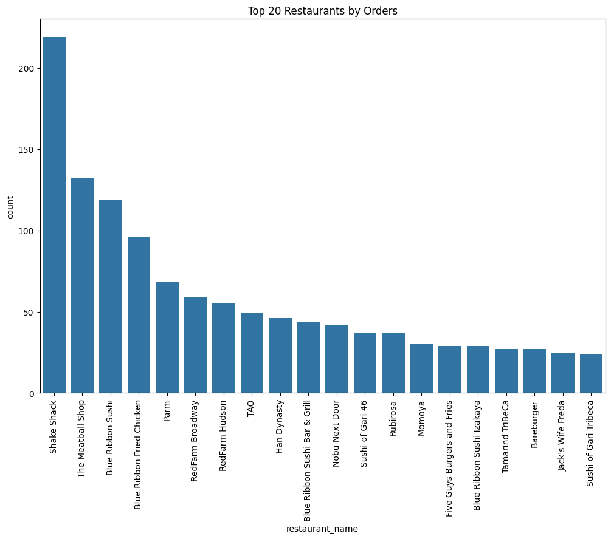

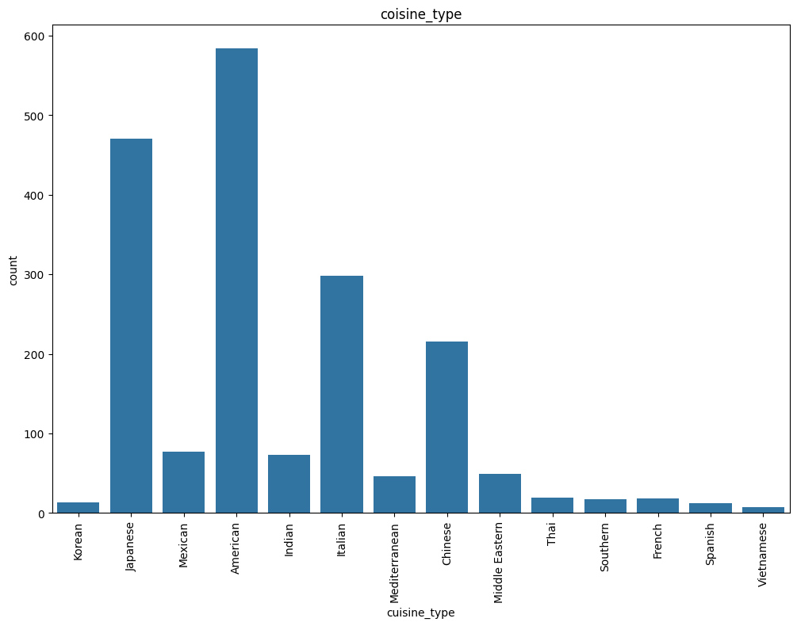

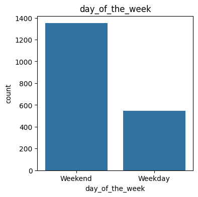

```python
plt.figure(figsize=(12, 8))

top20_restaurants = df['restaurant_name'].value_counts().head(20).index

# Filter the DataFrame to include only the top 20 restaurants
df_top20_restaurants = df[df['restaurant_name'].isin(top20_restaurants)]
sns.countplot(data=df, x='restaurant_name',order=top20_restaurants)
plt.xticks(rotation=90)
plt.title("Top 20 Restaurants by Orders")
plt.show()

plt.figure(figsize=(12, 8))

sns.countplot(data=df, x='cuisine_type')

plt.xticks(rotation=90)

plt.title("coisine_type")

plt.show()

plt.figure(figsize=(4, 4))

sns.countplot(data=df, x='day_of_the_week')


plt.title("day_of_the_week")

plt.show()
```

Observations: There are 14 unique cuisines in the dataset. The distribution of cuisine types show that cuisine types are not equally distributed. The most frequent cuisine type is American followed by Japanese and Italian. Vietnamese appears to be the least popular of all the cuisines.

Weekend shows higher order compare to weedays.

The restaurant that has received maximum number of orders is Shake Shack

### **Question 7**: Which are the top 5 restaurants in terms of the number of orders received? [1 mark]

```python
# Write the code here

df['restaurant_name'].value_counts().sort_values(ascending=False).head(5)
```

| restaurant_name | count |
| --- | --- |
| Shake Shack | 219 |
| The Meatball Shop | 132 |
| Blue Ribbon Sushi | 119 |
| Blue Ribbon Fried Chicken | 96 |
| Parm | 68 |

**dtype:** int64

#### Observations:

Shake Shank,The Meatball Shop, Blue Ribbon Sushi, Blue Ribbon Fried Chicken and Parm are the top 5 restaurants in terms of the number of orders received.

### **Question 8**: Which is the most popular cuisine on weekends? [1 mark]

```python
# Write the code here
df[df['day_of_the_week'] == 'Weekend']['cuisine_type'].value_counts().head(1)
```

| cuisine_type | count |
| --- | --- |
| American | 415 |

**dtype:** int64

```
cuisine_type
American    415
Japanese    335
Italian     207
Chinese     163
Mexican      53
Name: count, dtype: int64
```

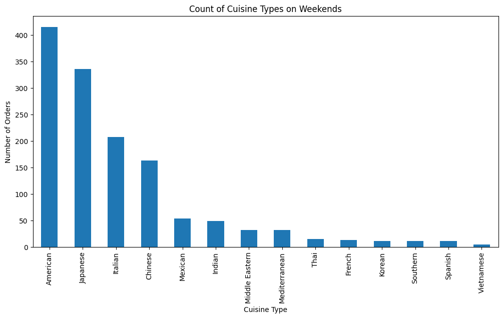

```python
# Filter data for weekends
weekend_data = df[df['day_of_the_week'] == 'Weekend']

# Get the count of each cuisine type on weekends
weekend_cuisine_counts = weekend_data['cuisine_type'].value_counts()

# print(weekend_data.head(5))
print(weekend_cuisine_counts.head(5))

plt.figure(figsize=(12, 6))

weekend_cuisine_counts.plot(kind='bar')
plt.xlabel('Cuisine Type')
plt.ylabel('Number of Orders')
plt.title('Count of Cuisine Types on Weekends')
plt.show()
```

#### Observations:

American(415) is the most popular restaurents.

### **Question 9**: What percentage of the orders cost more than 20 dollars? [2 marks]

```python
# Write the code here

total_order = len(df)
cost_more_than_20 = len(df[df['cost_of_the_order'] > 20])

Percentage = (cost_more_than_20 /total_order)*100

print(Percentage)
```

```
29.24130663856691
```

#### Observations:

29.24% of all orders cost more than 20 dollars.

### **Question 10**: What is the mean order delivery time? [1 mark]

```python
# Write the code here

print(df['delivery_time'].mean())
```

```
24.161749209694417
```

#### Observations:

Order delivery mean time: 24.16

### **Question 11:** The company has decided to give 20% discount vouchers to the top 3 most frequent customers. Find the IDs of these customers and the number of orders they placed. [1 mark]

```
customer_id
52832    13
47440    10
83287     9
Name: count, dtype: int64
```

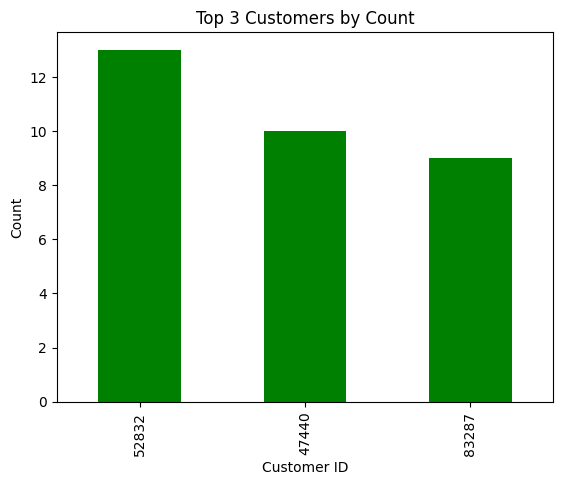

```python
# Write the code here

top_3_customers = df['customer_id'].value_counts().head(3)
print(top_3_customers)

top_3_customers.plot(kind='bar', color='green')
plt.title("Top 3 Customers by Count")
plt.xlabel("Customer ID")
plt.ylabel("Count")
plt.show()
```

#### Observations:

Customers 52832, 47440 and 83287 have placed 13, 10 and 9 orders respectively, which makes them the top three most frequent customers.

### **Question 12**: Perform a multivariate analysis to explore relationships between the important variables in the dataset. (It is a good idea to explore relations between numerical variables as well as relations between numerical and categorical variables) [10 marks]

```python
Cuisine vs Cost of the order
```

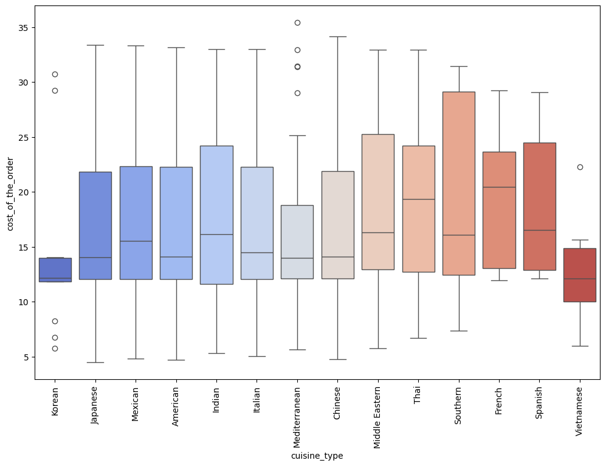

```python
# Write the code here

plt.figure(figsize=(12,8))
sns.boxplot(x = "cuisine_type", y = "cost_of_the_order", data = df, palette = 'coolwarm')
plt.xticks(rotation = 90)
plt.show()
```

Observations: Vietnamese and Korean cuisines cost less compared to other cuisines. The boxplots for Italian, American, Chinese, Japanese cuisines are quite similar. This indicates that the quartile costs for these cuisines are quite similar. Outliers are present for the cost of Korean, Mediterranean and Vietnamese cuisines. French is costlier compared to other cuisines.

Cuisine vs Food Preparation time

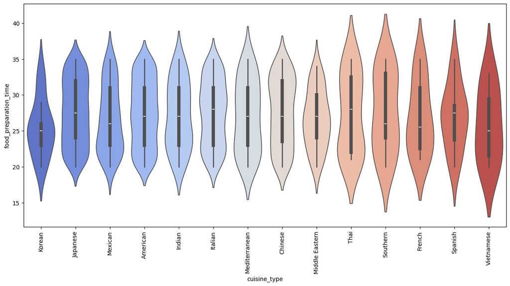

```python
plt.figure(figsize=(15,7))
sns.violinplot(x = "cuisine_type", y = "food_preparation_time", data = df,palette = 'coolwarm')
plt.xticks(rotation = 90)
plt.show()
```

Across all cuisine types, food preparation times are fairly consistent, typically ranging from 20–35 minutes, with slight variation where Korean, Southern, and French are a bit faster, while Italian, Japanese, Thai, and Indian lean slightly slower.

Day of the Week vs Delivery time

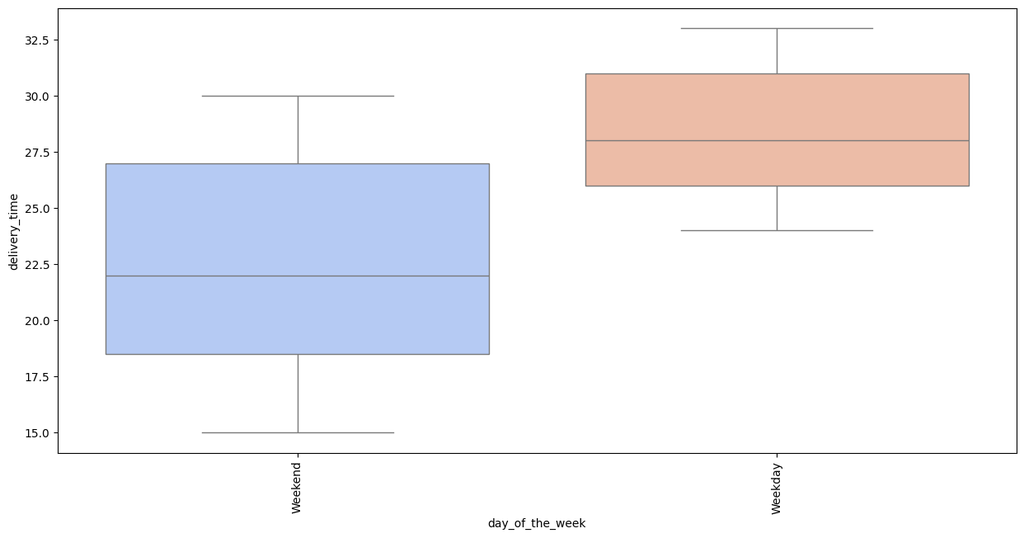

```python
plt.figure(figsize=(15,7))
sns.boxplot(x = "day_of_the_week", y = "delivery_time", data = df,palette = 'coolwarm')
plt.xticks(rotation = 90)
plt.show()
```

cuisine_type Vs cost_of_the_order

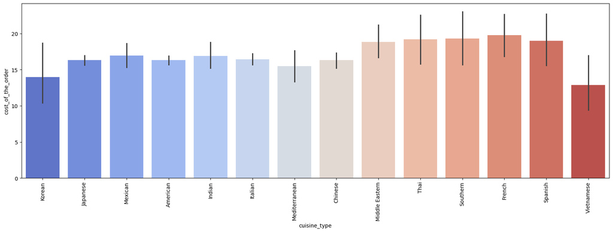

```python
plt.figure(figsize=(20,6))
sns.barplot(x='cuisine_type', y='cost_of_the_order', data=df,palette = 'coolwarm')
plt.xticks(rotation=90);
```

Vietnamese and Korean cuisines are the cheapest, while Middle Eastern, Thai, Southern, French, and Spanish cuisines tend to be the most expensive, with greater variability in order costs.

Rating vs Delivery time

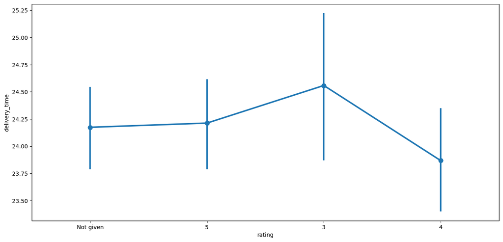

```python
plt.figure(figsize=(15, 7))
sns.pointplot(x = 'rating', y = 'delivery_time', data = df)
plt.show()
```

Observations : It is possible that delivery time plays a role in the low-rating of the orders.

Rating vs Food preparation time

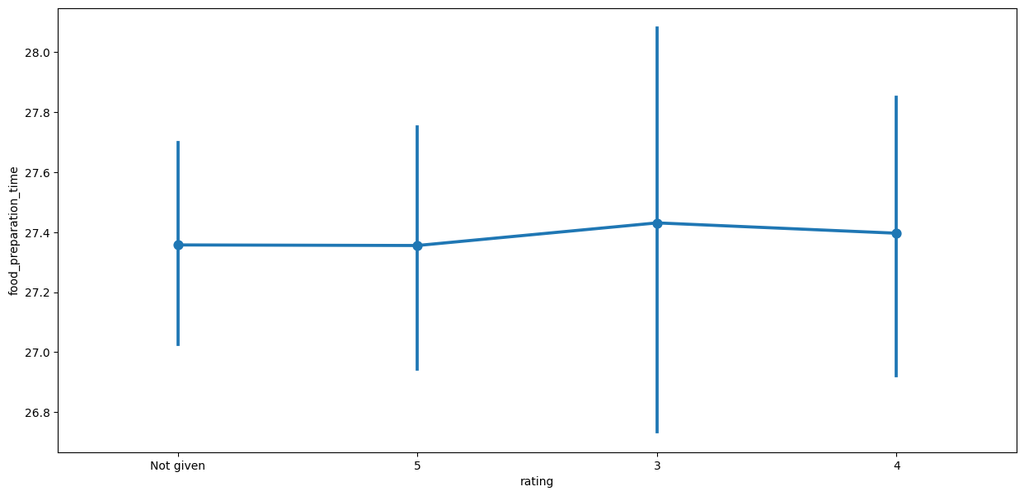

```python
plt.figure(figsize=(15, 7))
sns.pointplot(x = 'rating', y = 'food_preparation_time', data = df)
plt.show()
```

Observations:It seems that food preparation time does not play a role in the low-rating of the orders.

```python
Rating vs Cost of the order
```

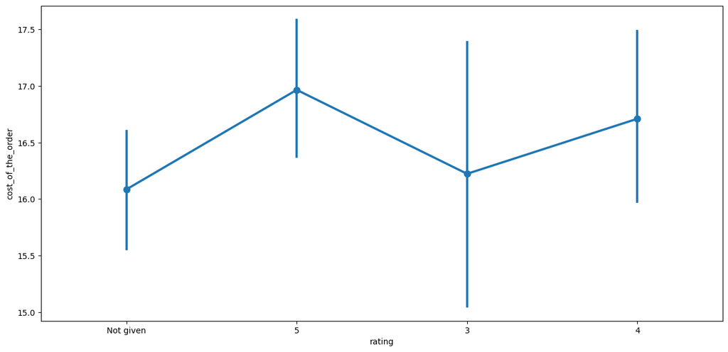

```python
plt.figure(figsize=(15, 7))
sns.pointplot(x = 'rating', y = 'cost_of_the_order', data = df)
plt.show()
```

Correlation among variables

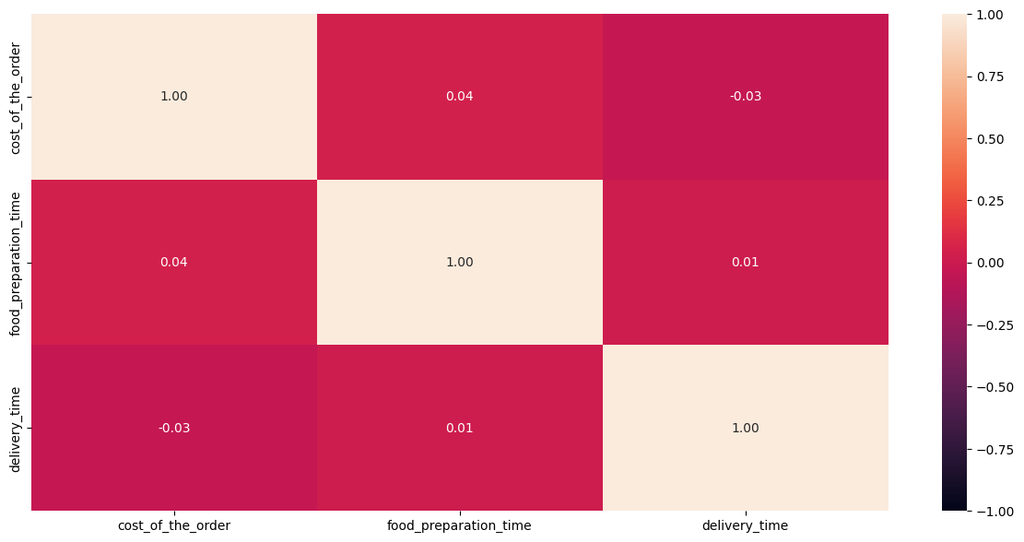

```python
Heat_list = ['cost_of_the_order', 'food_preparation_time', 'delivery_time']
plt.figure(figsize=(15, 7))
sns.heatmap(df[Heat_list].corr(), annot=True, vmin=-1, vmax=1, fmt=".2f" )
plt.show()
```

Observations on Numerical Variable Relationships: There is no correlation between cost of the order, delivery time and food preparation time.

### **Question 13:** The company wants to provide a promotional offer in the advertisement of the restaurants. The condition to get the offer is that the restaurants must have a rating count of more than 50 and the average rating should be greater than 4. Find the restaurants fulfilling the criteria to get the promotional offer. [3 marks]

```python
# Write the code here

df1 = df[df['rating'] != 'Not given']
df1

df1['rating'] = df1['rating'].astype(int)

promo_restaurants = df1.groupby('restaurant_name')['rating'].agg(['count', 'mean']).reset_index()

promo_restaurants_eligible_restaurants = promo_restaurants[(promo_restaurants['count'] > 50) & (promo_restaurants['mean'] > 4)]

print(promo_restaurants_eligible_restaurants)
```

```
               restaurant_name  count      mean
16   Blue Ribbon Fried Chicken     64  4.328125
17           Blue Ribbon Sushi     73  4.219178
117                Shake Shack    133  4.278195
132          The Meatball Shop     84  4.511905
```

#### Observations:

Shake Shack, The Meatball Shop, Blue Ribbo Sushi and Blue Ribbon Fried Chicken all qualify for the promotion.

### **Question 14:** The company charges the restaurant 25% on the orders having cost greater than 20 dollars and 15% on the orders having cost greater than 5 dollars. Find the net revenue generated by the company across all orders. [3 marks]

```python
# Write the code here

def calculated_revenue(cost_of_the_order):
  if cost_of_the_order > 20:
    return cost_of_the_order * 0.25
  elif cost_of_the_order > 5:
    return cost_of_the_order * 0.15

    return 0

df['revenue'] = df['cost_of_the_order'].apply(calculated_revenue)

total_revenue = df['revenue'].sum()
print(total_revenue)
```

```
6166.303
```

#### Observations:

The net revenue is $6166.303 across all orders.

### **Question 15:** The company wants to analyze the total time required to deliver the food. What percentage of orders take more than 60 minutes to get delivered from the time the order is placed? (The food has to be prepared and then delivered.) [2 marks]

```python
# Write the code here

# Calculate the total time by adding food preparation time and delivery time
df['total_time'] = df['food_preparation_time'] + df['delivery_time']

# Calculate the number of orders that took more than 60 minutes
more_than_60 = (df['total_time'] > 60).sum()
print('more_than_60:',more_than_60 )
# Calculate the total number of orders
total_order = len(df)
print('total_order:',total_order)

# Calculate the percentage of orders that took more than 60 minutes
percentage_more_than_60 = round((more_than_60 / total_order) * 100,2)

print(percentage_more_than_60)
```

```
more_than_60: 200
total_order: 1898
10.54
```

#### Observations:

10.54% of all orders take more than 60 minutes to get delivered from the time the order is placed.

### **Question 16:** The company wants to analyze the delivery time of the orders on weekdays and weekends. How does the mean delivery time vary during weekdays and weekends? [2 marks]

```python
# Write the code here

df['delivery_time'].groupby(df['day_of_the_week']).mean()
```

| day_of_the_week | delivery_time |
| --- | --- |
| Weekday | 28.340037 |
| Weekend | 22.470022 |

**dtype:** float64

#### Observations:

Observations:The mean delivery time on weekdays is around 28 minutes whereas the mean delivery time on weekends is around 22 minutes. This could be due to the dip of traffic volume in the weekends.

### Conclusion and Recommendations

### **Question 17:** What are your conclusions from the analysis? What recommendations would you like to share to help improve the business? (You can use cuisine type and feedback ratings to drive your business recommendations.) [6 marks]

### Conclusions:

Customer Feedback Needs Attention

Nearly 39% of orders lack ratings, which introduces bias. Missing or mid-range ratings may hide customer dissatisfaction due to courtesy bias. Since about 50% of rated orders scored 5 stars, the existing ratings alone may present an overly optimistic view. Improving feedback collection is essential for an accurate assessment of quality.

Cuisine Preferences are Sentiment-Driven

Customers strongly prefer American, Japanese, Italian, and Chinese cuisines, suggesting choices are influenced by familiarity and visibility. A few restaurants, such as Shake Shack, Meatball Shop, and Blue Ribbon Sushi, dominate orders, showing a factor of brand loyalty and trust.

Delivery Predictability Matters

Preparation time and delivery time together determine overall order satisfaction. Since order times are fairly consistent, ensuring predictable delivery could strengthen perceived value.

Weekend Demand & Consistent Popularity

Weekends see higher orders compared to weekdays, indicating a time-based demand pattern. Cuisine preferences remain the same across weekdays and weekends, reinforcing their strong sentimental appeal.

### Recommendations:

To improve the customer experience and optimize restaurant promotions, I suggest the following recommendations:

Enhance Customer Feedback Collection  
Encourage customers to give clearer and more feedback by offering incentives like coupon discounts or special deals. Add follow-up surveys during the order process to collect better insights about the dining experience and service satisfaction.

Conduct Customer Demographics and Market Segmentation Research  
Look into customer demographics and market segments to find patterns and reasons behind the different order costs. Knowing which segments relate to higher or lower costs will help with advertising and pricing strategies that target specific customer groups.

Improve Delivery Time Efficiency and Consistency  
Work on reducing delivery times on weekdays and minimizing variability, especially on weekends. This could include increasing the delivery staff or using optimized route planning software. This will improve customer satisfaction by providing more reliable and timely delivery experiences.

Explore Customer Sentiment Analysis  
Examine perceptions related to different cuisines, how delivery time predictability impacts customer satisfaction, and how price affects value perception. The insights gained can help inform menu diversification strategies, like introducing hybrids or popular alternatives in restaurants with low-performing cuisines. It can also guide targeted advertising to increase the visibility of less popular cuisines.

Targeted Incentives and Discounts  
Provide special discounts to customers who complete ratings and surveys to boost engagement. Consider offering promotional pricing or prioritized delivery for popular and high-performing cuisines to reward quality and popularity.

Dynamic Pricing and Staffing Adjustments  
Use varying charges for restaurants based on menu price differences to ensure fair pricing and profitability. Increase the number of delivery personnel or extend delivery shifts during peak weekend hours to efficiently meet demand surges and maintain service quality.

By following these recommendations, FoodHub can use data-driven insights to improve customer engagement, streamline operations, and strengthen partnerships with restaurants, ultimately driving higher customer satisfaction and business growth.